# I. Introduction

In this analysis, I will explore game data on every pitch thrown during the 2020 MLB season. While a casual baseball fan can often tell the difference between a fastball and a curveball with just her naked eye, for certain pitches the line is easily blurred between multiple pitch types. Moreover, not all fastballs are created equally, differing by velocity, movement, spin, and other measured variables. The goal of this exploratory data analysis is to create pitch *subtypes* within the categories of "Fastball", "Curveball", "Slider", and etc. that we all know well (or at least think we do!).

For every pitch, I will take MLB's classified pitch types as given, the methodology for which is outlined by MLB's Technology Team [here](https://technology.mlblogs.com/mlb-pitch-classification-64a1e32ee079). I will use a combination of K-Means clustering and Principal Components Analysis to create and visualize pitch subtypes, separate for each type of pitch and for left-handed pitchers (LHPs) and right-handed pitchers (RHPs). Following from this analysis will be two different types of output, both useful in their own way:

1. A table showing which pitch subtypes performed the best in 2020 in terms of batted-ball data such as exit velocity and launch angle.
   - This analysis is meant to be exploratory/descriptive rather than predictive. The interpretation should not be that a certain subtype *causes* better or worse performance, especially given all the unusual aspects - including the smaller sample size - of the 2020 MLB season, but that there is an *association* that warrants further analysis.
2. A Video Player created as an RShiny web application that allows the user to select a subtype and view actual in-game pitches from the 2020 season that fall into that subtype.
   - The user can repeatedly view the same pitch or see several different pitches for a certain subtype.
   - This type of "descriptive visualization" is really useful for understanding the characteristics of different subtypes.

An [analysis of pitch subtypes and effective pitch pairings](https://s2.smu.edu/~camp/pubs/dvorocsik_sabr_analytics_2020.pdf) has been implemented by Joseph Camp, Gregory Dvorocsik, and Eno Sarris, and I extend on their great work in some important ways, including:

- In 2020, MLB [switched from Trackman to Hawkeye](https://technology.mlblogs.com/introducing-statcast-2020-hawk-eye-and-google-cloud-a5f5c20321b8) as the optical tracking technology that powers their Statcast platform. Currently, most of that Hawkeye data is not available to the public. But by scraping MLB's GUMBO feed through the MLB Stats API, I am able to obtain data on the Observed Spin Direction (see [here](https://baseballsavant.mlb.com/leaderboard/spin-direction-pitches?year=2020&min=75&sort=9&sortDir=asc&pitch_type=FF&throws=&playerName=&team=&pov=Pit) for a quick primer) for every pitch. Previously, this variable had to be inferred as it could not be directly measured, and I am excited to incorporate it into my analysis. **The pitch-by-pitch data for 2020 from MLB GUMBO will serve as my dataset.**
- By utilizing Principal Components Analysis, we can better visualize high-dimensional clusters of pitch subtypes in a 2-D representation. PCA will serve as a tool to see how well-separated the clusters are from one another.

```python
import numpy as np
import pandas as pd
import matplotlib.pyplot as plt
%matplotlib inline
import seaborn as sns
import os
import warnings
from scipy.stats import pearsonr
from sklearn.cluster import KMeans
from sklearn.preprocessing import StandardScaler
from sklearn.decomposition import PCA
from plotnine import *
import itertools
from adjustText import adjust_text
from IPython.display import Image, HTML, display
path='ENTER PATH HERE'
os.chdir(path)
pd.options.display.max_columns = 200
pd.options.display.max_rows = 200000
warnings.simplefilter('ignore')
```

```python
gumbo = pd.read_csv('sc_gumbo.csv')
```

# Data Cleaning

I start by importing the scraped MLB GUMBO data. (To better understand how I acquired that data, please refer to the README for a list of included files.) In addition to renaming many of the variables, I take the following cleaning steps:

1. I select only a subset of the 123 variables that could be relevant for the purposes of this analysis.
2. After checking the number of null values for relevant numeric fields, I limit the data to non-null values for those fields. Now, the only missing values are for batted-ball measurements when the batter did not make contact.
3. I limit to only actual pitches thrown. This eliminates warm-up pitches that the Hawkeye data also tracks.

```python
rel_columns = ['game_pk','game_year','game_date','playId','pitcher.id','pitcher.fullName','batter.id','batter.fullName',\
               'batSide.code','pitchHand.code','isPitch','count.balls','count.strikes','count.outs','atBatNum',\
               'pitchNumber','details.call.code','details.call.description','details.type.code',\
               'details.type.description','pitchData.startSpeed','pitchData.coordinates.x0',
               'pitchData.coordinates.z0','pitchData.coordinates.pfxX',\
               'pitchData.coordinates.pfxZ','pitchData.coordinates.pX','pitchData.coordinates.pZ',\
               'pitchData.coordinates.vX0','pitchData.coordinates.vY0','pitchData.coordinates.vZ0',\
               'pitchData.coordinates.aX','pitchData.coordinates.aY','pitchData.coordinates.aZ',\
               'pitchData.breaks.breakAngle','pitchData.breaks.breakLength','pitchData.breaks.breakY',\
               'pitchData.breaks.spinRate','pitchData.breaks.spinDirection','pitchData.extension',\
               'hitData.launchSpeed','hitData.launchAngle','hitData.trajectory','hitData.hardness',\
               'hitData.coordinates.coordX','hitData.coordinates.coordY','eventType']
new_names = ['game_pk','game_year','game_date','play_id','pitcher_id','pitcher_name','batter_id','batter_name',\
               'bat_side','pitch_hand','is_pitch','balls','strikes','outs','at_bat_num',\
               'pitch_num','call','call_des','pitch_type','pitch_des','start_speed','release_horiz',
               'release_vert','pfx_x','pfx_z','plate_x','plate_z','vx0','vy0','vz0','ax','ay','az',\
               'break_angle','break_length','break_y','spin_rate',\
               'spin_direction','extension','launch_speed','launch_angle','hit_trajectory','hit_hardness',\
               'hc_x','hc_y','event_type']
gumbo = gumbo[rel_columns].rename(columns=dict(zip(rel_columns,new_names))) #Keep only relevant vars and rename them
gumbo['pitch_hand'] = gumbo['pitch_hand']+'HP'
```

```python
before = gumbo.apply(lambda x: sum(x.isnull()),axis=0) #Display null counts for each field
gumbo_df = gumbo[gumbo['is_pitch']] #Limit to actual pitches thrown
gumbo_df = gumbo_df[(~gumbo_df['spin_rate'].isnull()) & (~gumbo_df['extension'].isnull())] #Limit to non-null data
gumbo_df = gumbo_df[~(gumbo_df['launch_speed'].isnull()) | ~(np.isin(gumbo_df['call'],['X','D','E']))]
after = gumbo_df.apply(lambda x: sum(x.isnull()),axis=0)
pd.concat([before, after], axis=1).rename(columns={0:'Null Before',1:'Null After'})
```

|  | Null Before | Null After |
| --- | --- | --- |
| game_pk | 0 | 0 |
| game_year | 0 | 0 |
| game_date | 0 | 0 |
| play_id | 23779 | 0 |
| pitcher_id | 0 | 0 |
| pitcher_name | 0 | 0 |
| batter_id | 0 | 0 |
| batter_name | 0 | 0 |
| bat_side | 0 | 0 |
| pitch_hand | 0 | 0 |
| is_pitch | 0 | 0 |
| balls | 0 | 0 |
| strikes | 0 | 0 |
| outs | 0 | 0 |
| at_bat_num | 0 | 0 |
| pitch_num | 29524 | 0 |
| call | 29524 | 0 |
| call_des | 29524 | 0 |
| pitch_type | 30269 | 0 |
| pitch_des | 30269 | 0 |
| start_speed | 30269 | 0 |
| release_horiz | 30269 | 0 |
| release_vert | 30269 | 0 |
| pfx_x | 30269 | 0 |
| pfx_z | 30269 | 0 |
| plate_x | 30269 | 0 |
| plate_z | 30269 | 0 |
| vx0 | 30269 | 0 |
| vy0 | 30269 | 0 |
| vz0 | 30269 | 0 |
| ax | 30269 | 0 |
| ay | 30269 | 0 |
| az | 30269 | 0 |
| break_angle | 30269 | 0 |
| break_length | 30269 | 0 |
| break_y | 30269 | 0 |
| spin_rate | 30614 | 0 |
| spin_direction | 30614 | 0 |
| extension | 30855 | 0 |
| launch_speed | 263707 | 232633 |
| launch_angle | 263707 | 232633 |
| hit_trajectory | 263404 | 232638 |
| hit_hardness | 263399 | 232633 |
| hc_x | 263416 | 232648 |
| hc_y | 263416 | 232648 |
| event_type | 0 | 0 |

Next, I chart the number of each pitch type that was thrown, along with a reference table to define the pitch type abbreviations:

| **Pitch Type** | **Abbreviation** |
| --- | --- |
| **Four-Seam Fastball** | **FF** |
| **Slider** | **SL** |
| **Sinker** | **SI** |
| **Change-up** | **CH** |
| **Curveball** | **CU** |
| **Cutter** | **FC** |
| Knuckle Curve | KC |
| Splitter | FS |
| Slow-Curve or "Eephus" | CS |
| Knuckleball | KN |
| Forkball | FO |

Based on the bar chart below, it looks like the top six pitch types are thrown much more frequently by both LHPs and RHPs than the remaining pitch types. To limit the scope of the analysis, I will work with just these types which are bolded in the table above.

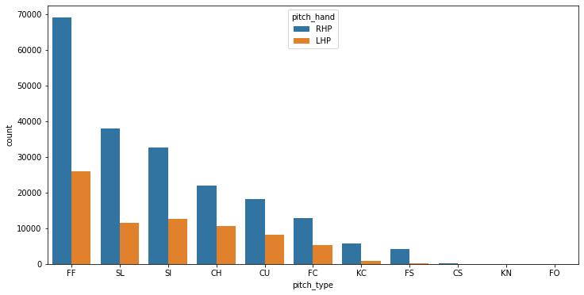

```python
fig, axes = plt.subplots(figsize=(12,6))
sns.countplot(data=gumbo_df, x='pitch_type',hue='pitch_hand',hue_order=['RHP','LHP'],
             order=gumbo_df['pitch_type'].value_counts().index)

#Rename 'pitch_type' variable from its abbreviation to full name for later visualizations:
gumbo_df = gumbo_df[np.isin(gumbo_df['pitch_type'],['FF','SL','SI','CH','CU','FC'])]
pitch_dict = {'FF':'Four-Seam Fastball','SL':'Slider','SI':'Sinker','CH':'Change-up','CU':'Curveball','FC':'Cutter'}
gumbo_df['pitch_type'] = gumbo_df['pitch_type'].map(pitch_dict)
```

# II. Data Visualization for Cluster Variables

Next, I will focus on the variables that play a role in determining pitch subtype. These are chosen from a mixture of domain knowledge of baseball and past research on pitch clustering. Because this is an unsupervised learning task, there is no "correct" recipe of variables that determine pitch subtype; even the pitch types seen above are often taken as gospel by baseball fans, but they are also determined through a classification algorithm that utilizes these same variables. We will take a further look at each piece of data in turn below.

## Velocity

The most obvious driver of pitch subtype is pitch velocity. A fastball thrown at 98 mph and one thrown at 90 mph clearly have different properties. I plot kernel density estimations of pitch velocity for each type, separately for LHPs and RHPs.

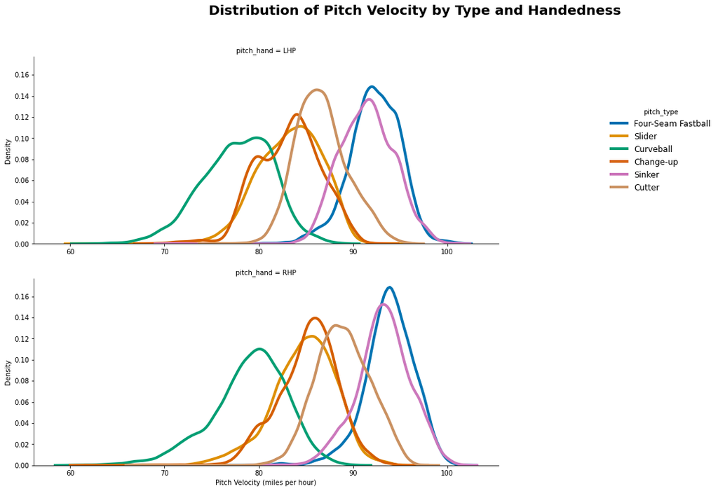

```python
gumbo_velo = gumbo_df[gumbo_df['start_speed']>60][['pitch_hand','pitch_type','start_speed']] #Get rid of outlier pitches <60 mph
g = sns.FacetGrid(data=gumbo_velo, row='pitch_hand',hue='pitch_type',palette='colorblind') #Faceted by pitcher hand, colored by pitch type
g = g.map(sns.kdeplot, 'start_speed',linewidth=4)
g.add_legend(bbox_to_anchor=(0.75,0.75),fontsize=12)
g.fig.set_size_inches(25,10)
for ax in g.axes.flatten():
    ax.tick_params(labelbottom=True)
g.fig.suptitle('Distribution of Pitch Velocity by Type and Handedness',fontsize=20,fontweight='bold',y=1.05)
g.set(xlabel='Pitch Velocity (miles per hour)',ylabel='Density');
```

Pitcher velocity has been measured (with varying levels of accuracy) and exalted for decades, but only in recent years has its interaction with other important variables like spin and movement been studied. We will investigate the interaction with spin rate below.

## Spin Rate

A pitch's spin rate can significantly alter the perceived velocity and movement of a pitch, as outlined in [this Driveline Basball article](https://www.drivelinebaseball.com/2016/11/spin-rate-what-we-know-now/). All else equal, a 92 mph fastball thrown at 2200 revolutions per minute (RPM) will drop less than one thrown at 1800 RPM, due to the [Magnus force](https://en.wikipedia.org/wiki/Magnus_effect) acting on the ball. Batters commonly say that high-spin pitches appear to "rise," an effect which, while not exactly true, is due to this Magnus force. **Note:** More spin is not unequivocally better or worse; only certain types of spin actual contribute to the movement of a pitch, and a full explanation is well outside the scope of this analysis. For now, we start by looking at the distribution of spin rate by pitch type and hand.

Immediately, we can see that Change-ups are characterized by their low spin rates, while Curveballs have a local peak in density around 2,900-3,000 RPM that is higher than the other pitches.

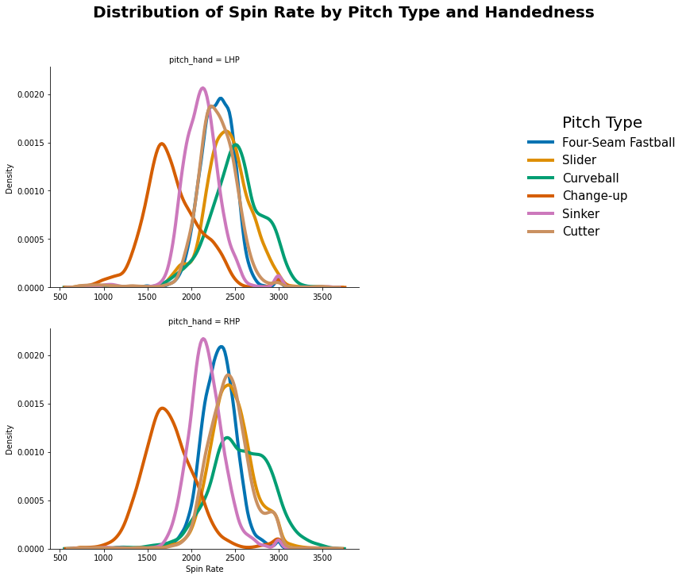

```python
g = sns.FacetGrid(data=gumbo_df, row='pitch_hand',hue='pitch_type',palette='colorblind') #Faceted by pitch type and hand
g = g.map(sns.kdeplot, 'spin_rate',linewidth=4) #Kernel density estimates of spin rate
g.add_legend(bbox_to_anchor=(0.8,0.75),fontsize=15)
g._legend.set_title('Pitch Type',{'size':20})
g.set(xlabel='Spin Rate',ylabel='Density')
g.fig.suptitle('Distribution of Spin Rate by Pitch Type and Handedness',fontsize=20,fontweight='bold',y=1.05)
g.fig.set_size_inches(20,10)
for ax in g.axes.flatten():
    ax.tick_params(labelbottom=True)
```

### Spin Rate vs Velocity ("Bauer Units")

The relationship between spin rate and velocity has changed the understanding of the Fastball. Driveline Baseball coined the term "Bauer Units" (BU) to denote the ratio between spin and velocity. Pitchers with high BU values have higher spin rates relative to other pitches thrown at the same velocity. As mentioned above, merely having a high-spin Fastball does not necessarily mean the pitch will produce a "rising" effect; spin direction - the next variable we explore - also plays a role. However, Bauer Units give a good indication as to which Fastballs may be more effective than just their velocity would suggest.

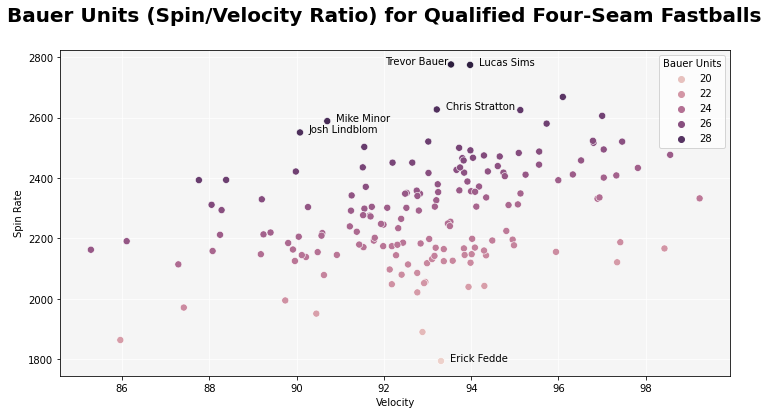

```python
qualified_pitchers = gumbo_df[['pitcher_name','pitch_hand']].value_counts().reset_index() #Get list of pitchers who threw >500 FF in 2020
qualified_pitchers = qualified_pitchers[qualified_pitchers[0]>500]
fastballs = gumbo_df[gumbo_df['pitch_type'] == 'Four-Seam Fastball']
bauer_units = pd.merge(fastballs[['pitcher_name','spin_rate','start_speed']],\
         qualified_pitchers,how='inner',on='pitcher_name').iloc[:,0:4] #Merge list of names back with original data
bauer_units = bauer_units.groupby('pitcher_name').mean().reset_index()
bauer_units['Bauer Units'] = bauer_units['spin_rate']/bauer_units['start_speed'] #Avg Bauer Units for qualified FF

fig, axes = plt.subplots(figsize=(12,6))
plt.grid(b=True, which='both', color='white', linestyle='-');
axes.set_axisbelow(True);
axes.set_facecolor('whitesmoke')
fig.suptitle('Bauer Units (Spin/Velocity Ratio) for Qualified Four-Seam Fastballs',fontsize=20,fontweight='bold')
axes.set_xlabel('Velocity')
axes.set_ylabel('Spin Rate')
sns.scatterplot(data=bauer_units, x='start_speed', y='spin_rate', hue='Bauer Units', s=50, ax=axes)
for i in range(len(bauer_units)): #Label outlier pitchers with very high or low BU values
    if bauer_units['pitcher_name'][i]=='Trevor Bauer':
         axes.text(bauer_units['start_speed'][i]-1.5, bauer_units['spin_rate'][i], \
               bauer_units['pitcher_name'][i], size='10', horizontalalignment='left')
    elif (bauer_units['Bauer Units'][i]>28) | (bauer_units['Bauer Units'][i]<20):
        axes.text(bauer_units['start_speed'][i]+0.2, bauer_units['spin_rate'][i], \
               bauer_units['pitcher_name'][i], size='10', horizontalalignment='left')
```

## Spin Direction (or Tilt)

Spin Direction refers to the direction a pitch travels due to its spin. Below is a nice graphic demonstrating spin direction for a Four-Seam Fastball and a Two-Seam Fastball. This hypothetical Four-Seamer spins at 180° or 12:00, representing pure backspin. The Two-Seamer, here thrown by a LHP, spins at about 165° or 11:30, and this spin will help to give it its characteristic horizontal movement (called "arm-side run").

(Credit to Sons of Sam Horn for the graphic.)

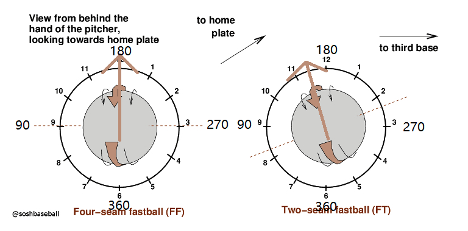

```python
Image(filename = path + "/img/Spin Direction.png")
```

As mentioned earlier, prior to the installation of Hawkeye cameras in 2020, spin direction could not be directly measured but only inferred using the physics of a projectile in motion. To compare inferred spin direction with the observed data from MLB GUMBO, I use [Dr. Alan Nathan's spreadsheet](http://baseball.physics.illinois.edu/trajectory-calculator-new3D.html) to calculate inferred spin, a process which is pretty complex and demonstrates the data improvements thanks to Hawkeye. I then reimport the data and merge inferred spin onto the main dataframe.

```python
#Export to Excel to use Alan Nathan's Inferred Spin Direction formula
gumbo_export = gumbo_df[['game_pk','at_bat_num','pitch_num','pitch_type','plate_x','plate_z','vx0','vy0','vz0',\
                     'ax','ay','az','pfx_x','pfx_z','spin_rate','extension','release_horiz','release_vert',\
                     'start_speed']]
gumbo_export.to_csv('sc_gumbo_lim.csv',index=False)
```

```python
#Re-import with Inferred Spin Direction
inferred_spin = pd.read_csv('sc_gumbo_inferred_spin.csv');
inferred_spin['phi'] = np.where(inferred_spin['phi']>360,inferred_spin['phi']-360,inferred_spin['phi']) #Rescale pitches with spin direction >360 degrees
inferred_spin = inferred_spin[['game_pk','at_bat_num','pitch_num','phi']].rename(columns={'phi':'inf_spin_direction'}) #"Phi" is how Dr. Nathan denotes inferred spin
gumbo_df = pd.merge(gumbo_df, inferred_spin, how='left', on=['game_pk','at_bat_num','pitch_num']); #Merge with main data
```

Now, I calculate the average spin direction for every pitch type for both LHPs and RHPs and plot the results on polar coordinates.

**Note on interpretation:** The distance from the center of the circle has no meaning; I simply place each pitch type along its own concentric circle. The angle/time measurement is what we really care about here.

We can glean a few things from the results:

1. Most pitches have mirror-image spin directions for LHPs and RHPs, which makes perfect sense.
2. Four-Seamers, Sinkers, and Cutters (all types of Fastballs) are within 1-2 hours of pure backspin.
3. Curveballs are much closer to 6:00, which represents pure topspin. This makes sense given how pitchers turn over (or supinate) their wrist when throwing a curve.
4. Changeups and Sliders have much more horizontal spin directions (i.e. sidespin)

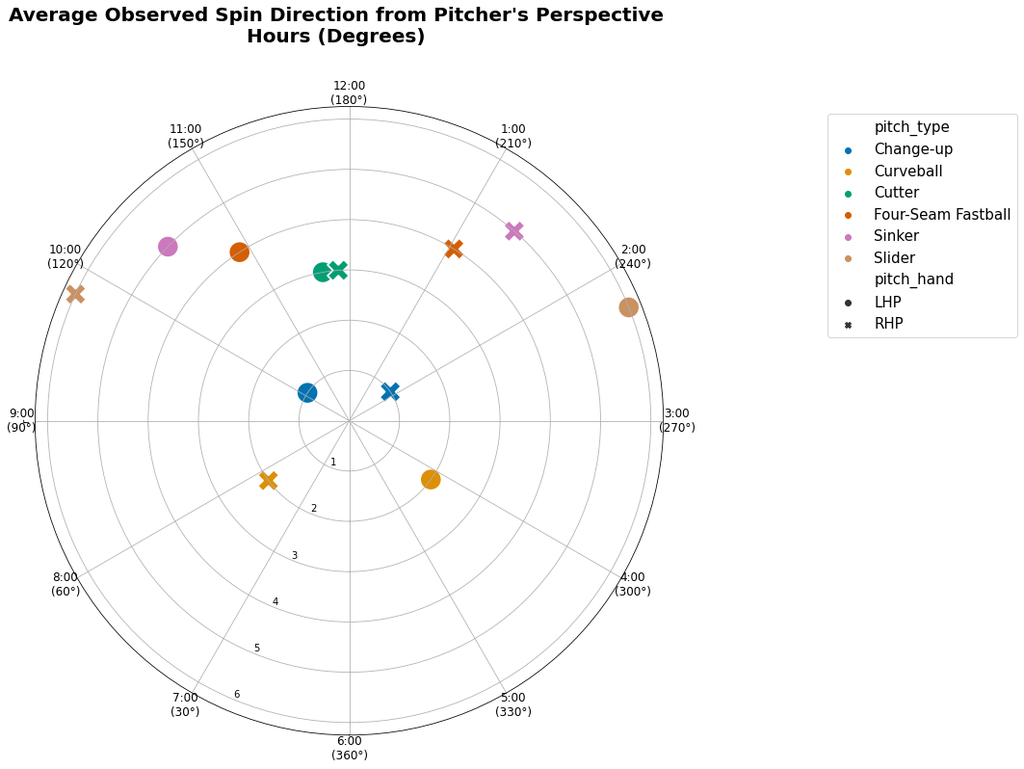

```python
gumbo_df['spin_radians'] = gumbo_df['spin_direction'].apply(lambda x: x/180.0*np.pi) #Convert degrees to radians
gumbo_lim = gumbo_df[['pitch_type','pitch_hand','spin_radians']]
gumbo_lim = gumbo_lim.groupby(['pitch_type','pitch_hand']).mean() #Calculate avg spin direction for each hand/type
gumbo_lim = gumbo_lim.reset_index()
gumbo_lim['r'] = [1,1,2,2,3,3,4,4,5,5,6,6] #Add radius variable so that each pitch type has its own concentric circle

plt.figure(figsize=(15,12))
axes = plt.subplot(111,polar=True)
axes.set_theta_zero_location("S")
axes.set_theta_direction(-1)
#Create labels with both clock and degree notation
labels=['6:00\n(360\u00b0)','7:00\n(30\u00b0)','8:00\n(60\u00b0)','9:00\n(90\u00b0)','10:00\n(120\u00b0)', \
       '11:00\n(150\u00b0)','12:00\n(180\u00b0)','1:00\n(210\u00b0)','2:00\n(240\u00b0)','3:00\n(270\u00b0)', \
       '4:00\n(300\u00b0)','5:00\n(330\u00b0)']

sns.scatterplot(data=gumbo_lim, x='spin_radians', y='r', hue='pitch_type',style='pitch_hand',\
                s=500,palette='colorblind')
plt.thetagrids(angles=np.linspace(0, 360, num=12, endpoint=False),\
               labels=labels, fontsize=12);
plt.legend(bbox_to_anchor=(1.25,1),fontsize=15)
plt.xlabel(None)
plt.suptitle('Average Observed Spin Direction from Pitcher\'s Perspective\nHours (Degrees)',fontsize=20,fontweight='bold',y=1);
```

## Inferred vs. Observed Spin Direction

As mentioned above, we can compare inferred and observed spin directions for each pitch type to see how much information is gained by being able to measure directly. Pitches with large discrepancies also suggest evidence of a ["Seam-Shifted Wake Effect"](https://www.drivelinebaseball.com/2020/11/more-than-what-it-seams-an-introduction-to-seam-shifted-wakes-and-their-effect-on-sinkers/) that again is outside the scope of this analysis. I examine the correlation between inferred and observed spin direction for all pitch types thrown by a pitcher at least 100 times in 2020. The correlations within most pitch types are extremely high, although the far lower number for Cutters is worth further investigation.

Ultimately, at the aggregate level, there turns out to be not much difference between inferred and observed spin, but a more in-depth analysis at the individual pitch level would undoubtedly reveal far larger discrepancies and is likely to be an area I explore in future analysis.

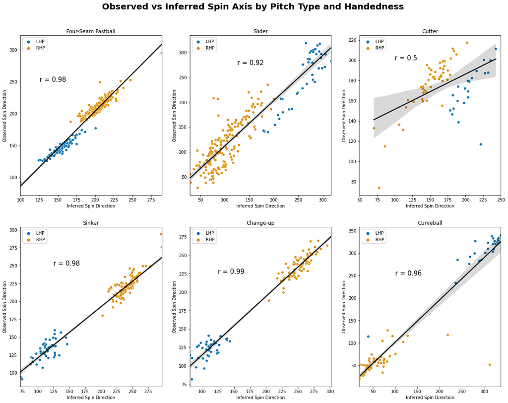

```python
#Get list of pitch types thrown at least 100 times by pitchers
qualified_pitches = gumbo_df[['pitcher_name','pitch_hand','pitch_type']].value_counts().reset_index()
qualified_pitches = qualified_pitches[qualified_pitches[0]>100].rename(columns={0:'count'}).drop(columns='count')

gumbo_spin = pd.merge(gumbo_df[['pitcher_name','pitch_hand','pitch_type','inf_spin_direction','spin_direction']], \
                      qualified_pitches, how='inner',on=['pitcher_name','pitch_type','pitch_hand']) #Merge back to original data
gumbo_spin = gumbo_spin.groupby(['pitcher_name','pitch_hand','pitch_type']).mean().reset_index() #Calculate avg spin direction
fig, axes = plt.subplots(2,3,figsize=(20,15))
axes=axes.ravel()

spin_list = []
titles=[]
for pitch in gumbo_spin['pitch_type'].unique():
    spin_list.append(gumbo_spin[gumbo_spin['pitch_type']==pitch])
    titles.append(pitch)
corr_loc = [[125,250],[125,275],[100,200],[125,250],[125,225],[100,250]]
for i in range(6):
    sns.scatterplot(data=spin_list[i], x='inf_spin_direction',y='spin_direction',hue='pitch_hand',\
                    hue_order=['LHP','RHP'], palette='colorblind',ax=axes[i])
    sns.regplot(data=spin_list[i], x='inf_spin_direction',y='spin_direction',scatter=False,ax=axes[i],color='black') #Plots linear regression line
    axes[i].set_title(titles[i])
    axes[i].set_xlabel('Inferred Spin Direction')
    axes[i].set_ylabel('Observed Spin Direction')
    if i == 2:
        axes[i].set_xlim([50,250])
    axes[i].legend(loc='upper left')

    corr = np.round(pearsonr(spin_list[i]['inf_spin_direction'], spin_list[i]['spin_direction'])[0],2) #Plots correlation coefficients
    axes[i].text(x=corr_loc[i][0],y=corr_loc[i][1],s='r = '+str(corr),size=15)
fig.suptitle('Observed vs Inferred Spin Axis by Pitch Type and Handedness',fontsize=20,fontweight='bold',y=0.95)
```

## Pitch Movement

Pitch movement is one of the most intuitive characteristics of a pitch, and often the quality that makes a pitch most recognizable. Charting movement for the same list of qualified pitches as in the chart above, we can see that again the same pitch thrown by a LHP and RHP tends to have mirrored movement. Sliders and Change-ups tend to move horizontally (in opposite directions), Curveballs drop, and Four-Seam Fastballs "rise." Note that pitches with positive vertical movement are not actually rising; this simply measures the "differential movement" compared with a pitch that has zero spin and is only acted upon by gravity. Increasingly coveted in the current landscape are pitchers who can throw "pure backspin" Four-Seam Fastballs with high spin and vertical movement because batters have a tendency to swing underneath them.

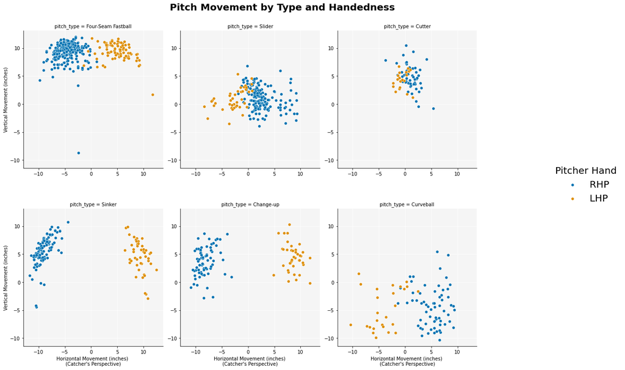

```python
avg_mvmt = pd.merge(gumbo_df[['pitcher_name','pitch_type','pfx_x','pfx_z']],\
         qualified_pitches,how='inner',on=['pitcher_name','pitch_type']).iloc[:,0:5].rename(columns={'pitch_type_x':'pitch_type'}) #Qualified pitchers
avg_mvmt = avg_mvmt.groupby(['pitcher_name','pitch_type','pitch_hand']).mean().reset_index()
g = sns.FacetGrid(data=avg_mvmt, col='pitch_type', height=2, col_wrap=3,hue='pitch_hand',palette='colorblind') #Faceted by pitch type and hand
g = g.map(sns.scatterplot, 'pfx_x','pfx_z')
g.add_legend(fontsize=20)
g.fig.set_size_inches(20,12)
g.set(xlabel='Horizontal Movement (inches) \n(Catcher\'s Perspective)',ylabel='Vertical Movement (inches)',\
     facecolor='whitesmoke',axisbelow=True)
g.fig.suptitle("Pitch Movement by Type and Handedness",fontsize=20,fontweight='bold')
g._legend.set_title("Pitcher Hand",prop={'size':20})
for ax in g.axes.flatten():
    ax.tick_params(labelbottom=True,labelleft=True)
    ax.grid(b=True,which='both',color='white',linestyle='-')
```

# Release Point

Generally, pitchers tend to have similar release points for all their pitches. So instead of looking at release point by pitch type, it's more instructive to see the average release point among all pitches for a given pitcher.

In the clustering analysis, release point is expected to play a relevant role because of the differing effects that similar pitches can have when thrown from distinct arm slots. Below are the average release points grouped by all pitches thrown by qualified pitchers, as well as labeled outliers. I've also included links to video of pitches thrown by both Pete Fairbanks and Ryan Thompson, who are labeled on the chart below, in order to better visualize what distinct release points actually look like. As is apparent from the videos, Fairbanks has an over-the-top release point, while Thompson throws from a side-arm slot.

[Link to video of Pete Fairbanks](https://baseballsavant.mlb.com/sporty-videos?playId=2794c7b7-a2c6-44f9-a757-64976bd8a1ce)

[Link to video of Ryan Thompson](https://baseballsavant.mlb.com/sporty-videos?playId=2bbd7173-a90c-4848-baa0-ecd39d13474d)

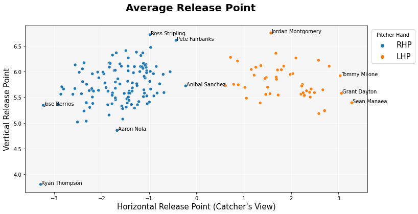

```python
avg_release = pd.merge(gumbo_df[['pitcher_name','release_horiz','release_vert']],\
         qualified_pitchers,how='inner',on='pitcher_name').iloc[:,0:4]
avg_release = avg_release.groupby('pitcher_name').mean().reset_index() #Get average release among ALL pitches grouped by qualified pitchers
avg_release=pd.merge(avg_release,qualified_pitchers,how='inner',on=['pitcher_name']).iloc[:,0:4]
plt.figure(figsize=(12,6))
plt.grid(b=True, which='both', color='white', linestyle='-');
s = sns.scatterplot(data=avg_release,x='release_horiz',y='release_vert',hue='pitch_hand')
s.set(facecolor='whitesmoke',axisbelow=True)
s.set_xlabel('Horizontal Release Point (Catcher\'s View)',fontsize=15)
s.set_ylabel('Vertical Release Point',fontsize=15)
s.legend(bbox_to_anchor=(1.15,1),fontsize=15,title='Pitcher Hand')
for i in range(len(avg_release)): #Label outliers
    if (avg_release['release_vert'][i] > 6.5) | (avg_release['release_vert'][i] < 5.0) | \
       (abs(avg_release['release_horiz'][i]) > 3.0) | (abs(avg_release['release_horiz'][i]) < 0.5):
        s.text(avg_release['release_horiz'][i]+0.02, avg_release['release_vert'][i], \
               avg_release['pitcher_name'][i], size='10', horizontalalignment='left')
plt.suptitle('Average Release Point',fontsize=20,fontweight='bold');
```

## Extension

Finally, the last variable considered is extension, which measures how much closer a pitcher is to home plate when he releases the ball. For pitchers with high extension (i.e. tall pitchers or those with long wingspans), the pitch can appear to "jump at" the batter, as it essentially travels a shorter distance. Like spin rate, extension can change the perceived velocity of a pitch.

Below, for qualified pitchers, I plot average extension as well as the overall estimated density of extension, separately for LHPs and RHPs. Most of the positive outlier pitchers are at least 6'4", with Tyler Glasnow, who is 6'8", being notorious for his elite pitch extension.

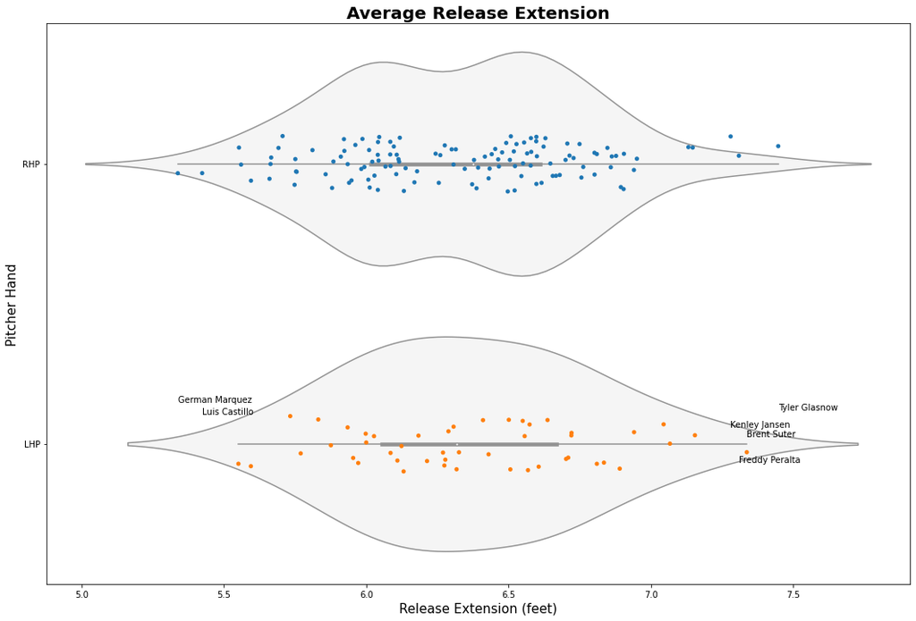

```python
avg_ext = pd.merge(gumbo_df[['pitcher_name','extension']],\
         qualified_pitchers[['pitcher_name','pitch_hand']],how='inner',on='pitcher_name') #Get qualified pitchers
avg_ext = avg_ext.groupby(['pitcher_name','pitch_hand']).mean().reset_index() #Calculate avg extension
fig, axes = plt.subplots(figsize=(18,12))
s=sns.stripplot(data=avg_ext,x='extension',y='pitch_hand',jitter=0.1) #1D scatter of extension, faceted by pitcher handedness
sns.violinplot(data=avg_ext,x='extension',y='pitch_hand',color='whitesmoke') #Violin plot with density of avg extension data
axes.set_title('Average Release Extension',fontsize=20,fontweight='bold')
axes.set_xlabel('Release Extension (feet)',fontsize=15)
axes.set_ylabel('Pitcher Hand',fontsize=15)
np.random.seed(1)
for i in range(len(avg_ext)): #Label outliers
    if (avg_ext['extension'][i] > 7.25) | (avg_ext['extension'][i] < 5.5):
        if avg_ext['pitch_hand'][i]=='R':
            s.text(avg_ext['extension'][i],0+np.random.uniform(-.15,.15),avg_ext['pitcher_name'][i], size='10',horizontalalignment='left')
        else:
            s.text(avg_ext['extension'][i],1+np.random.uniform(-.15,.15),avg_ext['pitcher_name'][i], size='10',horizontalalignment='left')
```

# III. Clustering Analysis

To cluster each pitch, I first need to determine how many subtypes each pitch should have, which is sometimes more of an art than a science. I want enough subtypes to encourage diversity, but not too many so as to introduce redundancy and cause sample size issues within each cluster. For every pitch type/hand combination, I implement K-Means clustering using all of the numeric variables I just detailed above, for values of K ranging from 1 to 10. The within-cluster sum of squares for each run are plotted below.

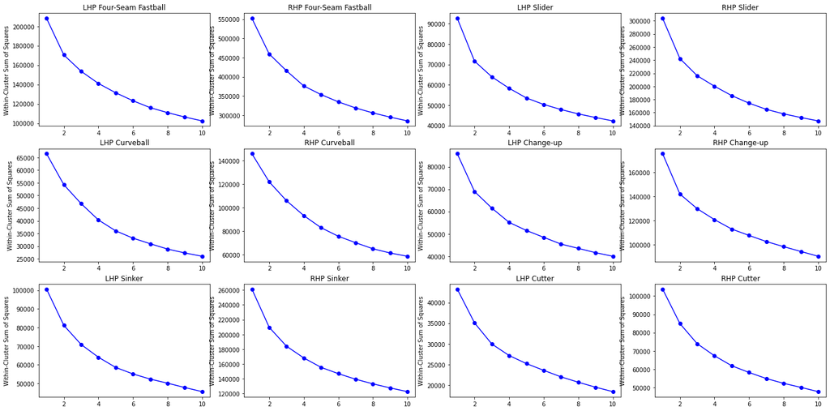

```python
pitches = ['Four-Seam Fastball','Slider','Curveball','Change-up','Sinker','Cutter']
pitch_short = ['FF','SL','CU','CH','SI','FC']
hands = ['LHP','RHP']

def calc_wcss(pitch,hand):
    '''
    This function calculates the within-cluster sum of squares (WCSS) for a K-Means clustering analysis for
    a specific pitch type and pitcher handedness. WCSS is generated for K=1 to K=10 to faciliate plotting.
    '''
    gumbo_subset = gumbo_df[(gumbo_df['pitch_type']==pitch) & (gumbo_df['pitch_hand']==hand)]
    gumbo_subset = gumbo_subset[['start_speed','release_vert','release_horiz',\
                     'extension','spin_rate','spin_direction','pfx_x','pfx_z']]
    cluster_data = StandardScaler().fit_transform(gumbo_subset) #Scale data before clustering to account for differing units
    wcss = []
    for i in range(1,11):
        km = KMeans(n_clusters=i, n_init=20, max_iter=300).fit(cluster_data) #Run K-Means for various K
        wcss.append(km.inertia_) #Generate list of WCSS values for plotting
    return(wcss)

np.random.seed(1)
pitch, hand = zip(*itertools.product(pitches,hands))
wcss = list(map(calc_wcss, pitch, hand))

#WCSS Plots for every pitch type-hand combo
fig, axes = plt.subplots(3,4,figsize=(24,12))
for j,ax in enumerate(axes.flat):
    ax.plot(range(1,11),wcss[j],'bo-')
    ax.set_title(hand[j]+' '+pitch[j])
    ax.set_ylabel('Within-Cluster Sum of Squares')
```

A common approach is to use the "elbow method" to choose a value of K by looking for a elbow-like shape in the WCSS plot. I also could have calculated a gap statistic to determine K in a more systematic way, but as I mentioned, I'm okay with a more subjective process given the exploratory nature of the analysis. Based on domain knowledge, there should probably be at least 3 subtypes for every pitch, and the upper bound could be as high as 7 or 8 for some pitches. However, to limit the scope of this analysis, since I do this clustering for 12 different pitch types, 3-4 subtypes per pitch seems about right.

Once I determine a subtype for every single pitch in the dataset, I calculate the cluster averages (i.e. centroids) across all included dimensions and depict them in a heatmap. This is the first of multiple ways I will visualize the pitch subtypes, so to avoid repetitiveness I will move onto the next technique.

```python
k = (3,3,3,3,3,3,4,4,3,3,3,3) #Number of clusters for each pitch type
def kmeans(pitch,hand,k): #Rerun K-Means for each pitch type, only for the chosen value of K
    gumbo_subset = gumbo_df[(gumbo_df['pitch_type']==pitch) & (gumbo_df['pitch_hand']==hand)]
    gumbo_subset = gumbo_subset[['start_speed','release_vert','release_horiz',\
                     'extension','spin_rate','spin_direction','pfx_x','pfx_z']]
    cluster_data = StandardScaler().fit_transform(gumbo_subset)
    km = KMeans(n_clusters=k, n_init=20, max_iter=300).fit(cluster_data)
    gumbo_subset['cluster'] = km.labels_
    gumbo_subset['pitch_type'] = pitch
    gumbo_subset['pitch_hand'] = hand
    return gumbo_subset


clusts = list(map(kmeans,pitch,hand,k))
```

```python
gumbo_clusts = pd.concat(clusts)
gumbo_clusts.sort_index(inplace=True)

#Reformat cluster names and map them back to original data
pitch_dict_inv = dict(zip(pitch_dict.values(),pitch_dict.keys()))
gumbo_df['cluster'] = gumbo_clusts['pitch_hand']+'-'+\
                      gumbo_clusts['pitch_type'].apply(lambda x:pitch_dict_inv[x])+\
                      (gumbo_clusts['cluster']+1).astype(str)
```

```python
#Calculate cluster averages
cluster_avg = gumbo_df[['start_speed','release_vert','release_horiz',\
        'extension','spin_rate','spin_direction','pfx_x','pfx_z','cluster']].groupby('cluster').mean().reset_index()

#Standardized cluster averages
standardize_vars = ['start_speed','release_vert','release_horiz','extension','spin_rate','spin_direction',\
                   'pfx_x','pfx_z']
for var in standardize_vars: #Scale variables for heat map
    cluster_avg[var] = (cluster_avg[var] - cluster_avg[var].mean())/cluster_avg[var].std()

cluster_avg[['pitch_hand','subtype']] = cluster_avg['cluster'].str.split('-').tolist()

cluster_avg = cluster_avg.drop(columns='cluster').melt(id_vars=('pitch_hand','subtype'),\
                               value_vars=('start_speed','release_vert','release_horiz','extension',\
                                           'spin_rate','spin_direction','pfx_x','pfx_z'))
cluster_avg['pitch_type'] = cluster_avg['subtype'].apply(lambda x:x[0:2])
```

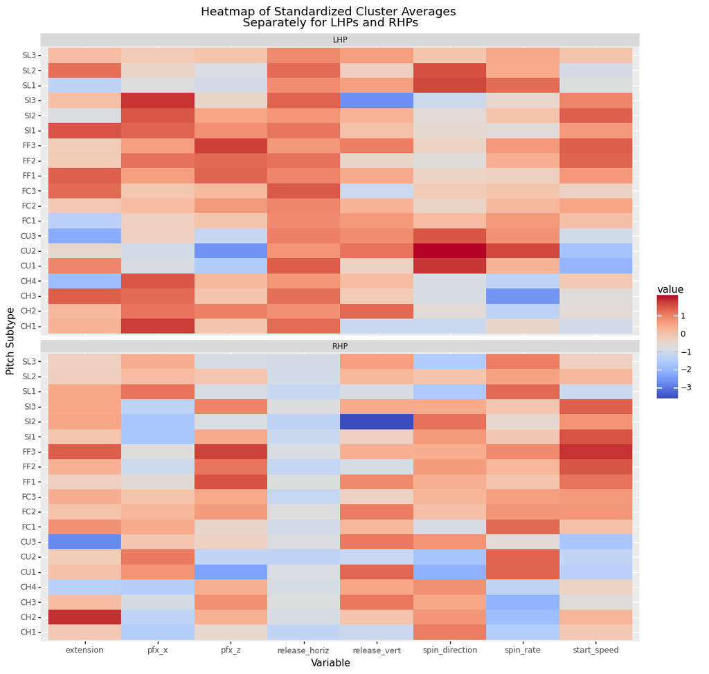

```python
(ggplot(cluster_avg, aes(x='variable',y='subtype',fill='value')) + geom_tile() + facet_wrap('pitch_hand',nrow=2) + \
    xlab('Variable') + ylab('Pitch Subtype') + ggtitle('Heatmap of Standardized Cluster Averages \nSeparately for LHPs and RHPs') +\
    scale_fill_continuous('coolwarm') + theme(figure_size=(12,12))).draw();
```

# Principal Components Analysis applied to Clusters

Principal Components allows for a lower-dimensional embedding of the data that captures as much of the variation in the original features used for clustering as possible. In this case, the goal of PCA is to reduce the cluster variables to just two dimensions so that the human eye can visualize how well-separated they are. For most pitches, the first 2 principal components capture ~40-50% of the total variance, which is certainly adequate for the purposes of this visualization.

For a given pitch type, I plot the data in two dimensions, labeled and colored by their subtype. I only present two of the 12 examples below to save time and space, but they paint a good overall picture.

- The 2-SD ellipses suggest pretty decent separation, albeit with some overlap in the middle.
- The rug plots along the axes give us an idea of the spread of the data along each dimension, and we can see very distinctive bunches of color that suggest very nice cluster separation.

All in all, considering just how many factors categorize every pitch and how much noise there is in measurement and interaction of those factors, K-Means and PCA perform very well here.

```python
def plot_PCA(pitch,hand):
    gumbo_subset = gumbo_df[(gumbo_df['pitch_type']==pitch) & (gumbo_df['pitch_hand']==hand)]
    pca_data = gumbo_subset[['start_speed','release_vert','release_horiz',\
                     'extension','spin_rate','spin_direction','pfx_x','pfx_z']]
    pca_data = StandardScaler().fit_transform(pca_data) #Scale data
    pca = PCA(n_components=2).fit(pca_data) #Run PCA and extract first 2 PCs
    pca_data = pca.fit_transform(pca_data)
    pca_data = pd.concat([pd.DataFrame(pca_data), gumbo_subset['cluster'].reset_index()], axis=1).rename(columns={0:'PC1',1:'PC2'}).drop(columns='index')
    pca_data['cluster'] = pca_data['cluster'].apply(lambda x:x[-1])

    g = ggplot(pca_data, aes(x='PC1',y='PC2', color='cluster',label='cluster')) +\
        geom_rug() + geom_text(alpha=0.5) + \
        stat_ellipse(aes(group='cluster'),level=0.95,size=2,color='black',linetype='dashed') +\
        labs(x='Principal Component 1', y='Principal Component 2',color='Subtype') +\
        ggtitle('2-D Representation of Pitch Subtypes \n'+pitch+' ('+hand+')') +\
        theme(figure_size=(12,12))

    return g
```

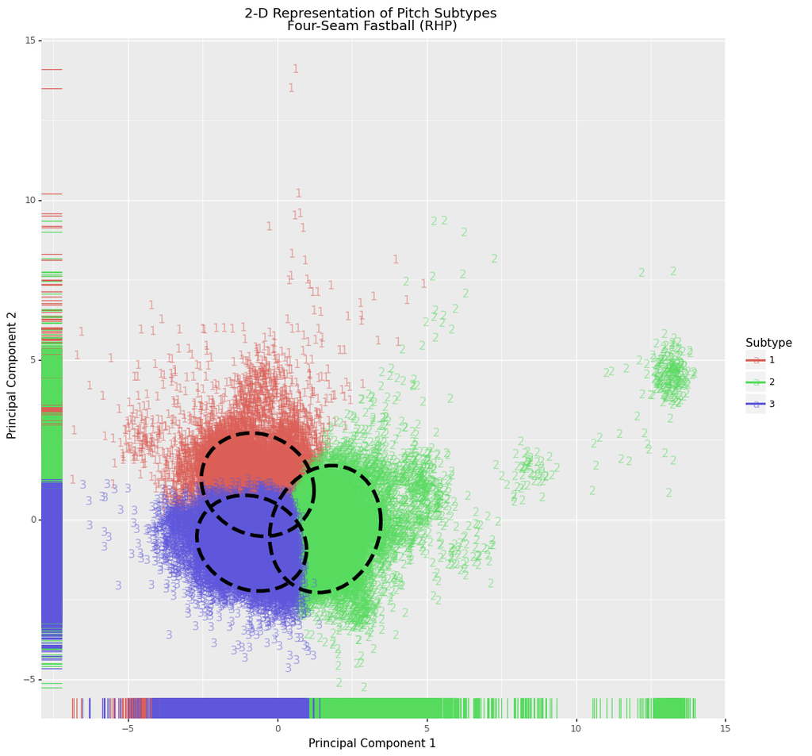

```python
(plot_PCA('Four-Seam Fastball','RHP')).draw();
```

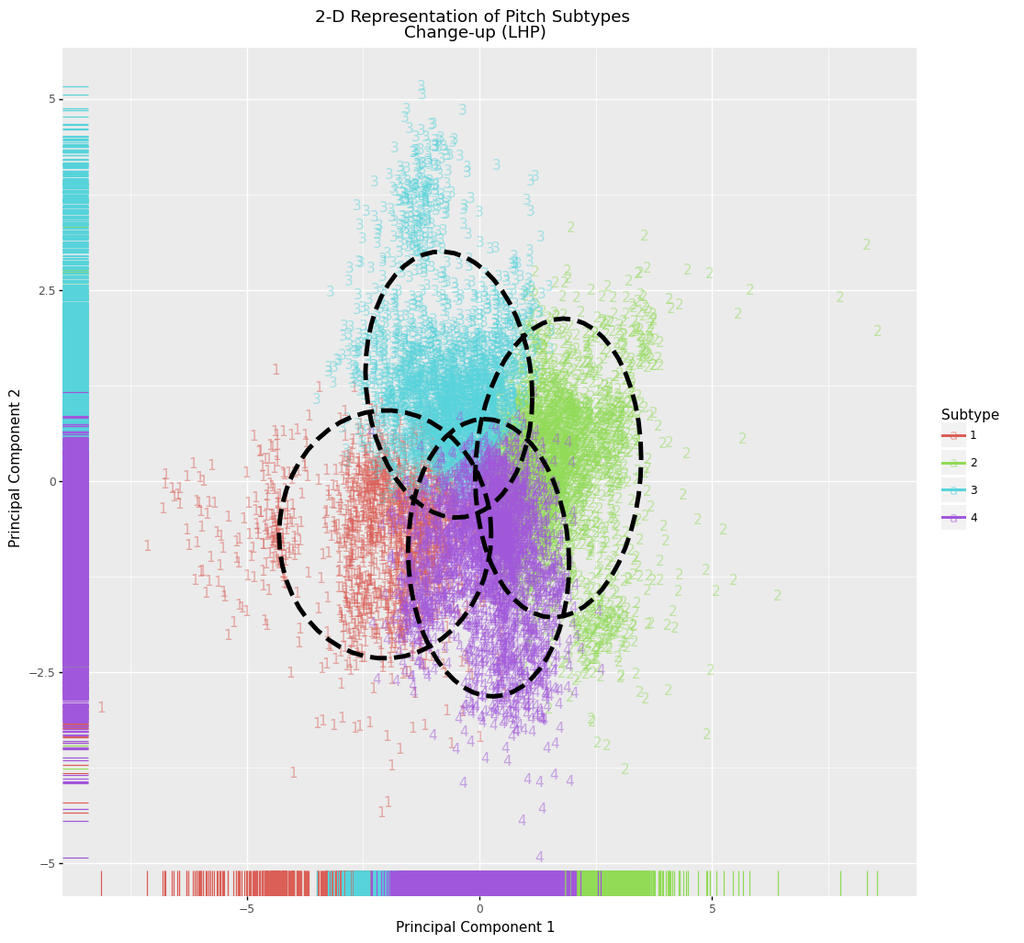

```python
(plot_PCA('Change-up','LHP')).draw();
```

# IV. Conclusions

## Pitch Subtype Performance

I present jitter plots of two metrics of pitch subtype performance below, separate for LHPs and RHPs and colored by the number of pitches in each subtype to give a sense of sample size:

As stated at the beginning of the analysis, these results are not predictive, but instead offer an association between certain subtypes and batter contact. There are also several other metrics that could be considered in future work, including Weighted On-Base Average (wOBA), Swinging Strike Percentage (SwStr%), and more. Because of this, I'm not going to conclude by proclaiming a certain Subtype "the best" one; I leave that to additional analysis that takes these clusters as an input and uses statistical learning to generate more powerful predictions. I will actually conclude by presenting my Video Player below, which really captures the essence of doing this analysis in the first place.

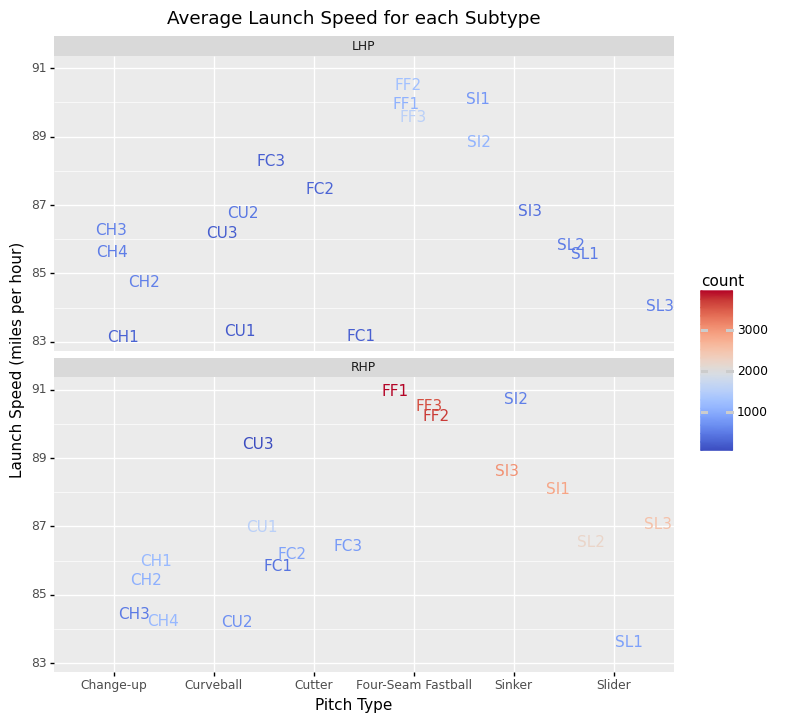

```python
np.random.seed(2013)
balls_inplay = gumbo_df[np.isin(gumbo_df['call'],['X','D','E'])] #Limit to only batted balls
balls_inplay['barrel'] = np.where((balls_inplay['launch_angle']<=50) & (balls_inplay['launch_speed']>=98) &\
                              (balls_inplay['launch_speed']*1.5-balls_inplay['launch_angle']>=117) &\
                              (balls_inplay['launch_speed']+balls_inplay['launch_angle']>=124),1,0) #Define barrel
balls_inplay = balls_inplay[['launch_speed','barrel','cluster']].groupby('cluster').agg(['count','mean']).reset_index() #Count and avg number of barrel
balls_inplay['pitch_type'] = balls_inplay['cluster'].apply(lambda x:pitch_dict[x[4:6]])
balls_inplay.columns = balls_inplay.columns.map(' '.join)
balls_inplay.rename(columns={'launch_speed mean':'avg_launch_speed','launch_speed count':'count',\
                             'cluster ':'cluster','pitch_type ':'pitch_type','barrel mean':'barrel_pct'},\
                    inplace=True)
balls_inplay.drop(columns='barrel count',inplace=True)
balls_inplay[['pitch_hand','subtype']] = balls_inplay['cluster'].str.split('-').tolist()
balls_inplay['barrel_pct'] = 100*balls_inplay['barrel_pct']

np.random.seed(2004)
(ggplot(balls_inplay,aes(x='pitch_type',y='avg_launch_speed',label='subtype',color='count')) + \
geom_text(position=position_jitter(0.5,1)) + scale_color_continuous('coolwarm') +\
facet_wrap('pitch_hand',nrow=2) + theme(figure_size=(8,8)) + labs(x='Pitch Type',y='Launch Speed (miles per hour)') +\
ggtitle('Average Launch Speed for each Subtype')).draw();
```

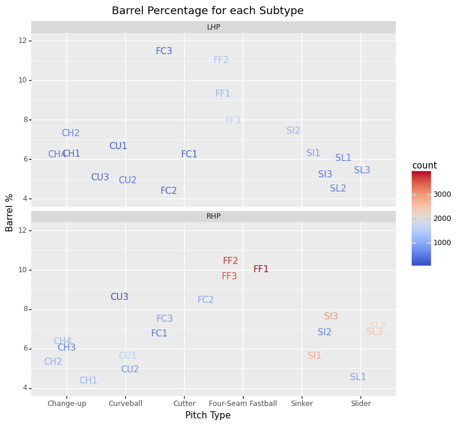

```python
np.random.seed(2000)
(ggplot(balls_inplay,aes(x='pitch_type',y='barrel_pct',label='subtype',color='count')) + \
scale_color_continuous('coolwarm') +\
geom_text(position=position_jitter(0.5,0.5)) + ylim(4,12) +\
facet_wrap('pitch_hand',nrow=2) + theme(figure_size=(8,8)) + labs(x='Pitch Type',y='Barrel %') +\
ggtitle('Barrel Percentage for each Subtype')).draw();
```

## Pitch Subtype Video Player

Last but not least, I present the most fun part of this analysis. Simply click on the Shiny app below, input a positive integer as the random seed, and choose your subtype to see a video. Changing the seed changes the videos generated for each subtype.

While I offer multiple visualization techniques of my new pitch subtypes above, watching actual baseball is easily the most informative and enjoyable way to really see how each of the pitch subtypes differ. I would argue that this is the most important piece of output from my exploratory data analysis and serves as a great robustness check that the subtypes I've created are logical. Special thanks to Baseball Savant and the entire MLBAM Technology Team for all the amazing ways they faciliate public access to baseball data. Enjoy!

**The Video Player can be accessed at this address:**

https://judah-axelrod.shinyapps.io/pitch-subtype-analysis/